# Pertemuan 5 MPDW

Rafi Akbar Wibawa

September 26, 2023

```r
library(ggplot2)
library(tsibble)
library(tseries)
library(MASS)
library(rio)
```

## Dataioner dalam Rataan dan Ragam

```r
Data1 <- import("https://raw.githubusercontent.com/rafi2411/MPDW-STA1341/main/Pertemuan-1/Raw%20Data.csv")
Data <- Data1$`NO2 (ug/m3)`
```

### Plot *Time Series*

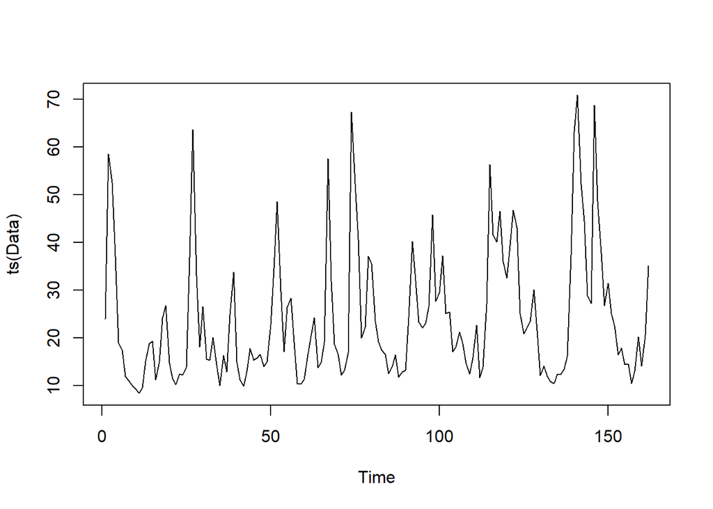

```r
plot.ts(ts(Data))
```

Plot deret waktu di atas menunjukkan bahwa data Data stasioner dalam rataan, ditandai dengan data yang menyebar di sekitar nilai tengahnya dan Data tidak stasionerioner dalam ragam, ditandai dengan lebar pita yang cenderung berubah-rubah dengan berpola musiman.

### Plot ACF

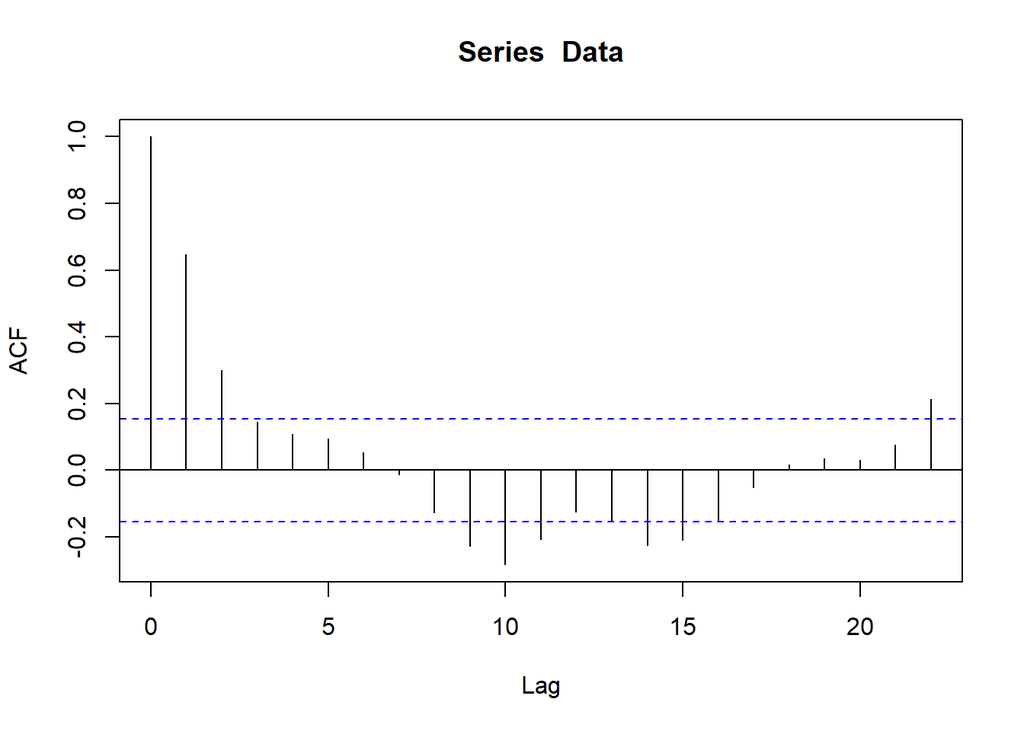

```r
acf(Data)
```

Berdasarkan plot ACF, terlihat bahwa plot ACF pada data tersebut cenderung *tails off* dan membentuk gelombang sinus. Hal ini menunjukkan bawa data stasioner secara rataan.

### Uji ADF

```r
tseries::adf.test(Data)
```

```
##
##  Augmented Dickey-Fuller Test
##
## data:  Data
## Dickey-Fuller = -4.6108, Lag order = 5, p-value = 0.01
## alternative hypothesis: stationary
```

$H_0$ : Data tidak Dataioner dalam rataan

$H_1$ : Data Dataioner dalam rataan

Berdasarkan uji ADF tersebut, didapat *p-value* sebesar 0.01 yang lebih kecil dari taraf nyata 5% sehingga tolak $H_0$ dan menandakan bahwa data Dataioner dalam rataan. Hal ini sesuai dengan hasil eksplorasi menggunakan plot time series dan plot ACF.

### Plot Box-Cox

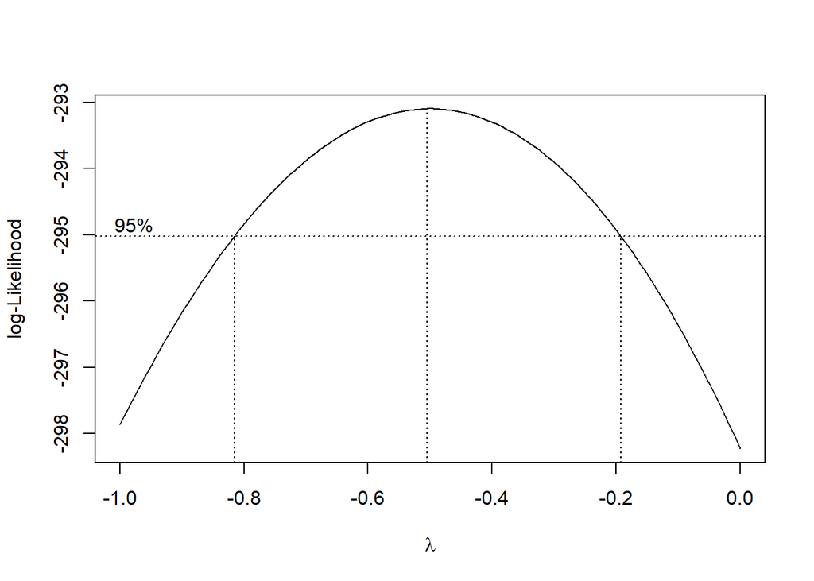

```r
index <- seq(1:length(Data))
bc = boxcox(Data~index, lambda = seq(-1,0,by=0.05))
```

```r
#Nilai Rounded Lambda
lambda <- bc$x[which.max(bc$y)]
lambda
```

```
## [1] -0.5050505
```

```r
#SK
bc$x[bc$y > max(bc$y) - 1/2 * qchisq(.95,1)]
```

[output not shown]

### Partisi Data

#### Bagian 1

```r
dt_Data1 <- Data[1:79] |> ts()
mean(dt_Data1)
```

```
## [1] 21.92278
```

```r
var(dt_Data1)
```

```
## [1] 182.4744
```

#### Plot Time Series

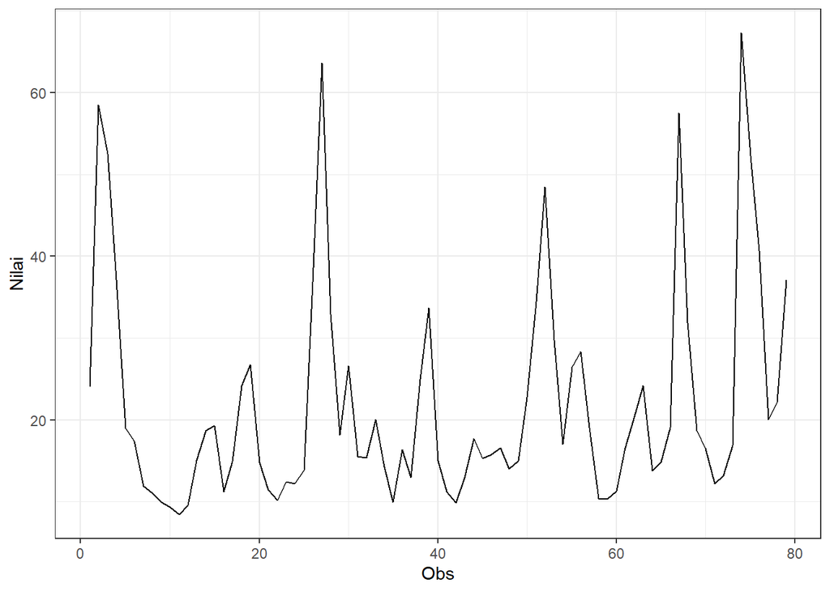

```r
dt_Data1 |> as_tsibble() |>
  ggplot(aes(x = index, y = value)) +
  geom_line() + theme_bw() +
  xlab("Obs") + ylab("Nilai")
```

Plot deret waktu di atas menunjukkan bahwa data Dataioner dalam rataan, ditandai dengan data yang menyebar di sekitar nilai tengahnya dan tetapi tidak Dataioner dalam ragam, ditandai dengan lebar pita yang cenderung berpola musiman.

#### Plot ACF

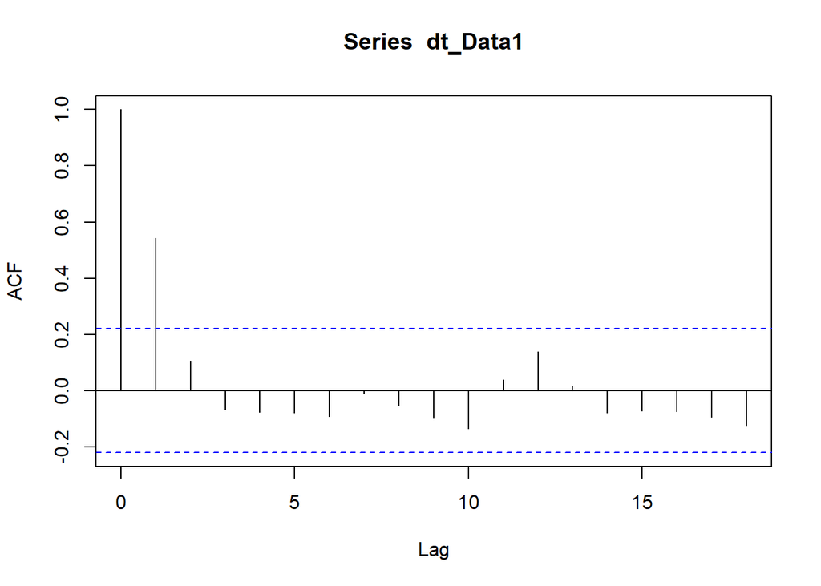

```r
acf(dt_Data1)
```

#### Uji ADF

```r
tseries::adf.test(dt_Data1)
```

```
##
##  Augmented Dickey-Fuller Test
##
## data:  dt_Data1
## Dickey-Fuller = -4.3642, Lag order = 4, p-value = 0.01
## alternative hypothesis: stationary
```

$H_0$ : Data tidak Dataioner dalam rataan

$H_1$ : Data Dataioner dalam rataan

Berdasarkan uji ADF tersebut, didapat *p-value* sebesar 0.01 yang lebih kecil dari taraf nyata 5% sehingga tolak $H_0$ dan menandakan bahwa data Dataioner dalam rataan. Hal ini sesuai dengan hasil eksplorasi menggunakan plot time series dan plot ACF.

#### Plot Boxcox

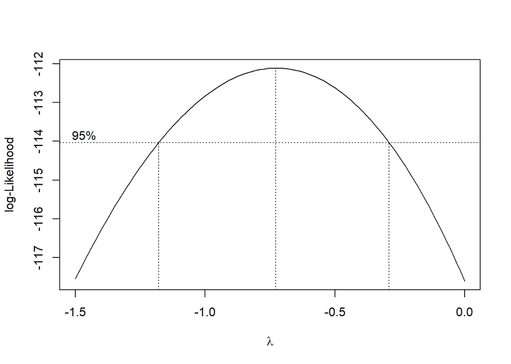

```r
index <- seq(1:79)
bc = boxcox(dt_Data1~index, lambda = seq(-1.5,0,by=0.5))
```

```r
#Nilai Rounded Lambda
lambda <- bc$x[which.max(bc$y)]
lambda
```

```
## [1] -0.7272727
```

```r
#SK
bc$x[bc$y > max(bc$y) - 1/2 * qchisq(.95,1)]
```

[output not shown]

Gambar di atas menunjukkan nilai *rounded value* ($\lambda$) optimum sebesar **-0.7272** dan pada selang kepercayaan 95% nilai memiliki batas bawah **-1,1667** dan batas atas **-0.3030**. Selang tersebut tidak memuat nilai satu sehingga dapat dikatakan bahwa data tidak Dataioner dalam ragam.

#### Bagian 2

```r
dt_Data2 <- Data[1:148] |> ts()
mean(dt_Data2)
```

```
## [1] 24.45149
```

```r
var(dt_Data2)
```

```
## [1] 202.9267
```

#### Plot Time Series

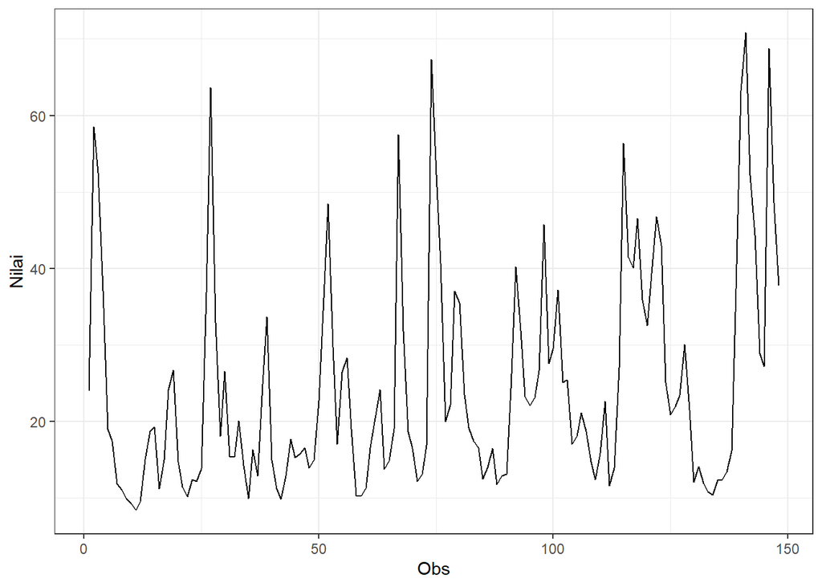

```r
dt_Data2 |> as_tsibble() |>
  ggplot(aes(x = index, y = value)) +
  geom_line() + theme_bw() +
  xlab("Obs") + ylab("Nilai")
```

#### Plot ACF

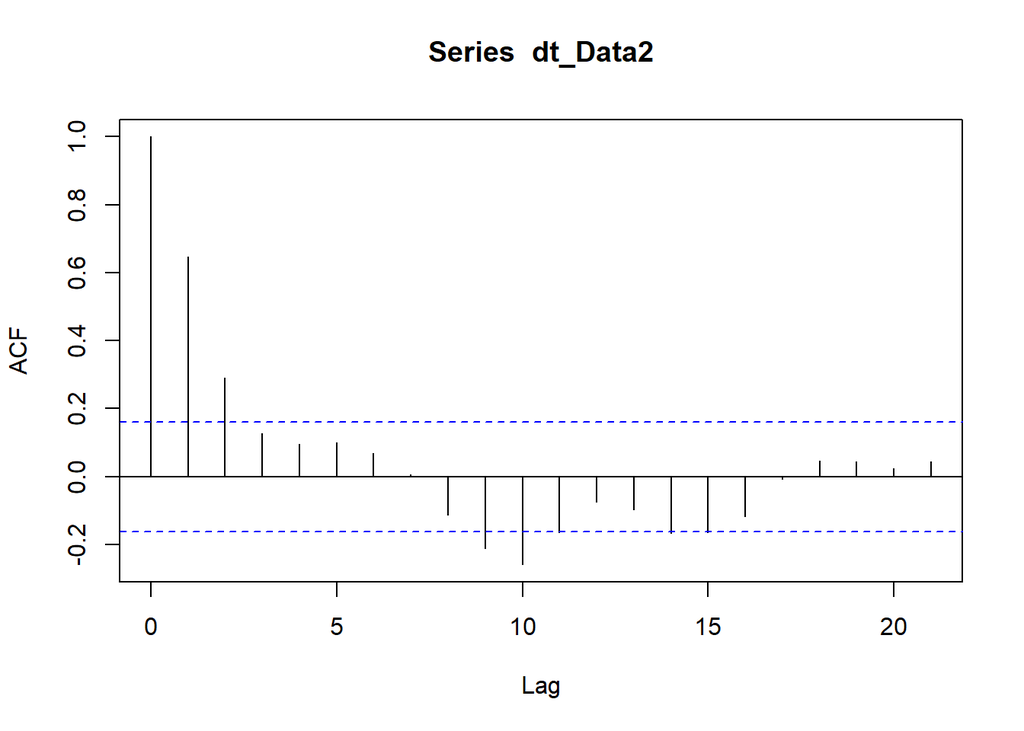

```r
acf(dt_Data2)
```

Berdasarkan plot ACF, terlihat bahwa plot ACF pada data tersebut cenderung *tails off* dan membentuk gelombang sinus.

#### Uji ADF

```r
adf.test(dt_Data2)
```

```
##
##  Augmented Dickey-Fuller Test
##
## data:  dt_Data2
## Dickey-Fuller = -4.4353, Lag order = 5, p-value = 0.01
## alternative hypothesis: stationary
```

$H_0$ : Data tidak Dataioner dalam rataan

$H_1$ : Data Dataioner dalam rataan

Berdasarkan uji ADF tersebut, didapat *p-value* sebesar 0.01 yang lebih kecil dari taraf nyata 5% sehingga tolak $H_0$ dan menandakan bahwa data Dataioner dalam rataan. Hal ini sesuai dengan hasil eksplorasi menggunakan plot time series dan plot ACF.

#### Plot Boxcox

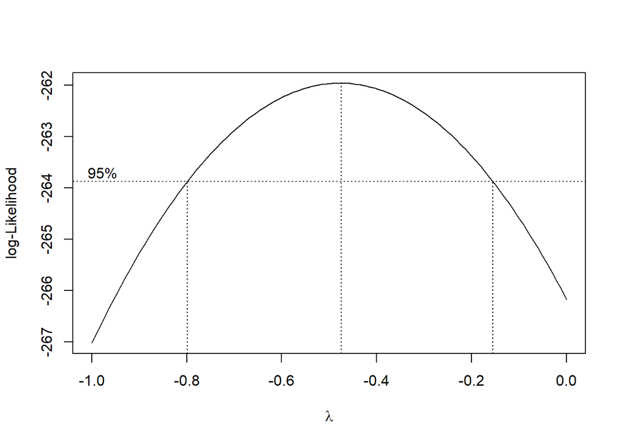

```r
index <- seq(1:148)
bc = boxcox(dt_Data2~index, lambda = seq(-1,0,by=0.5))
```

```r
#Nilai Rounded Lambda
lambda <- bc$x[which.max(bc$y)]
lambda
```

```
## [1] -0.4747475
```

```r
#SK
bc$x[bc$y > max(bc$y) - 1/2 * qchisq(.95,1)]
```

[output not shown]

Gambar di atas menunjukkan nilai *rounded value* ($\lambda$) optimum sebesar **-0.474** dan pada selang kepercayaan 95% nilai memiliki batas bawah **-0.797** dan batas atas **-0.1616**. Selang tersebut tidak memuat nilai satu sehingga dapat dikatakan bahwa data tidak Dataioner dalam ragam.